## Setup

### Load packages

```r
library(ggplot2)
library(dplyr)
library(statsr)
library(BAS)
```

### Load data

Make sure your data and R Markdown files are in the same directory. When loaded your data file will be called `movies`. Delete this note when before you submit your work.

```r
setwd("C:/Users/aalilooee/Dropbox/Baysian Statistics")
load("movies.Rdata")
#load("movies.Rdata")
```

## Part 1: Data

Our data contains information about 651 titles of movies released from 1970 to 2014. We have some aspect of theses movies like the genre, the date of release, scores they receive from different sources, how well they were in the box office and other relevant information. Our main goal here is to test what features make a movie popular. This data gives us some relevant information to test our required question.

## Part 2: Data manipulation

```r
feature_film=NULL;
Drama=NULL;
mpaa_rating_R=NULL;
oscar_season=NULL;
summer_season=NULL;
for(i in 1:651){
       if(movies$title_type[i]=="Feature Film"){
         feature_film[i]="yes"
           }else{
          feature_film[i]="no"
          }
       if(movies$genre[i]=="Drama"){
         Drama[i]="yes"
           }else{
          Drama[i]="no"
          }
        if(movies$mpaa_rating[i]=="R"){
          mpaa_rating_R[i]="yes"
          }else{
          mpaa_rating_R[i]="no"
                }
        if(is.element(movies$thtr_rel_month[i],c(10,11,12))){
            oscar_season[i]="yes"
        }else{
           oscar_season[i]="no"
        }
        if(is.element(movies$thtr_rel_month[i],c(5,6,7,8))){
            summer_season[i]="yes"
        }else{
           summer_season[i]="no"
        }

}
```

```r
movies=movies %>% as.data.frame() %>%
mutate(Drama=Drama,mpaa_rating_R=mpaa_rating_R,oscar_season=oscar_season,summer_season=summer_season,feature_film=feature_film)
```

## Part 3: Exploratory data analysis

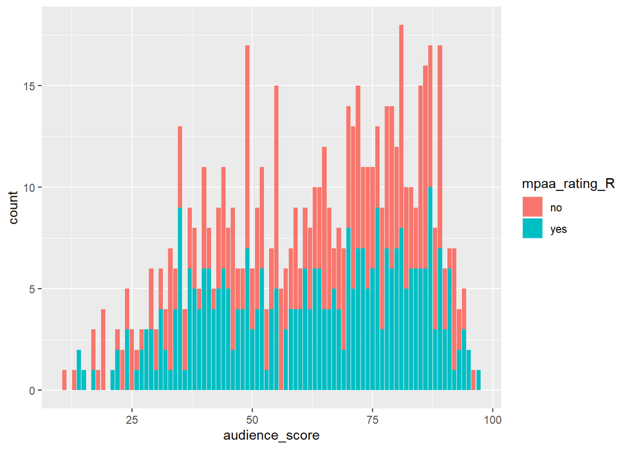

```r
ggplot(data=movies, aes(x = audience_score, fill = mpaa_rating_R)) +
  geom_bar()
```

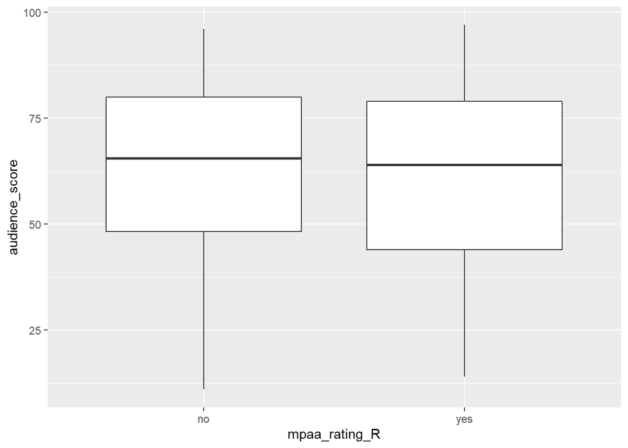

```r
ggplot(data=movies,mapping = aes(x=mpaa_rating_R,y=audience_score))+geom_boxplot()
```

```r
movies %>%
 group_by(mpaa_rating_R) %>%
        summarise(mean_score=mean(audience_score),Std.Dev.=sd(audience_score),
                  max_score=max(audience_score),min_score=min(audience_score))
```

```
## # A tibble: 2 x 5
##   mpaa_rating_R mean_score Std.Dev. max_score min_score
##   <chr>              <dbl>    <dbl>     <dbl>     <dbl>
## 1 no                  62.7     20.3        96        11
## 2 yes                 62.0     20.2        97        14
```

As the above plot and the summary we can find out the IMPAA rating doesn’t have a great impact on audience rate. In other words, we can see on average the audience score for movies with R IMPAA score is the same as the score for other IMPAA scores.

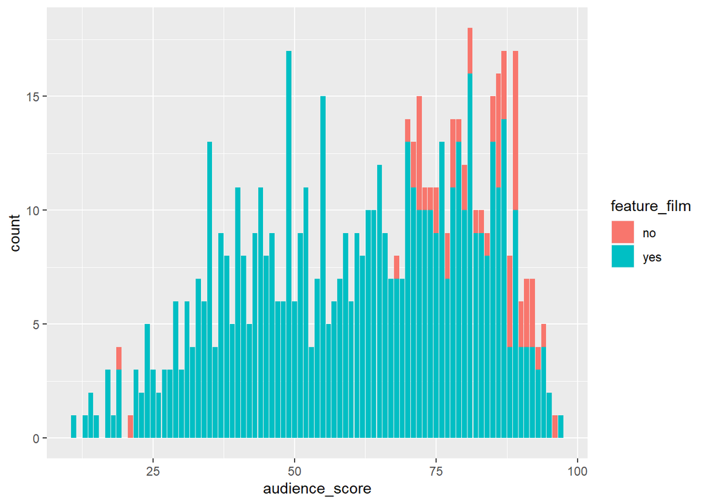

```r
ggplot(data=movies, aes(x = audience_score, fill = feature_film)) +
  geom_bar()
```

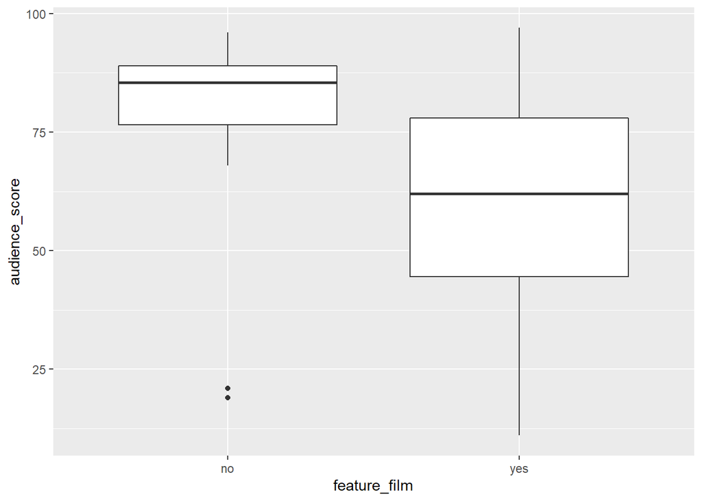

```r
ggplot(data=movies,mapping = aes(x=feature_film,y=audience_score))+geom_boxplot()
```

```r
movies%>%
 group_by(feature_film) %>%
 summarise(mean_score=mean(audience_score),Std.Dev.=sd(audience_score),max_score=
                   max(audience_score),min_score=min(audience_score))
```

```
## # A tibble: 2 x 5
##   feature_film mean_score Std.Dev. max_score min_score
##   <chr>             <dbl>    <dbl>     <dbl>     <dbl>
## 1 no                 81.0     13.6        96        19
## 2 yes                60.5     19.8        97        11
```

As we can see here even though the most movies in our data set are feature films but on average in the score that audiences gave to the movies which are not feature is higher. Then seems this type of movie has an impact on audience score.

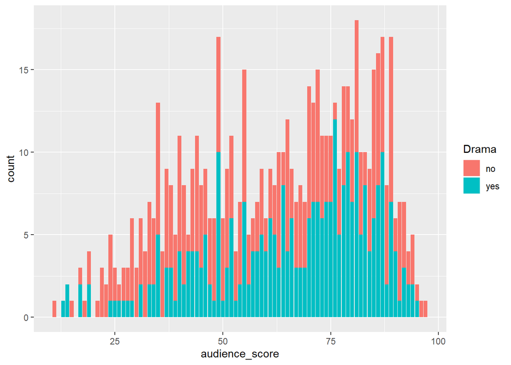

```r
ggplot(data=movies, aes(x = audience_score, fill = Drama)) +
  geom_bar()
```

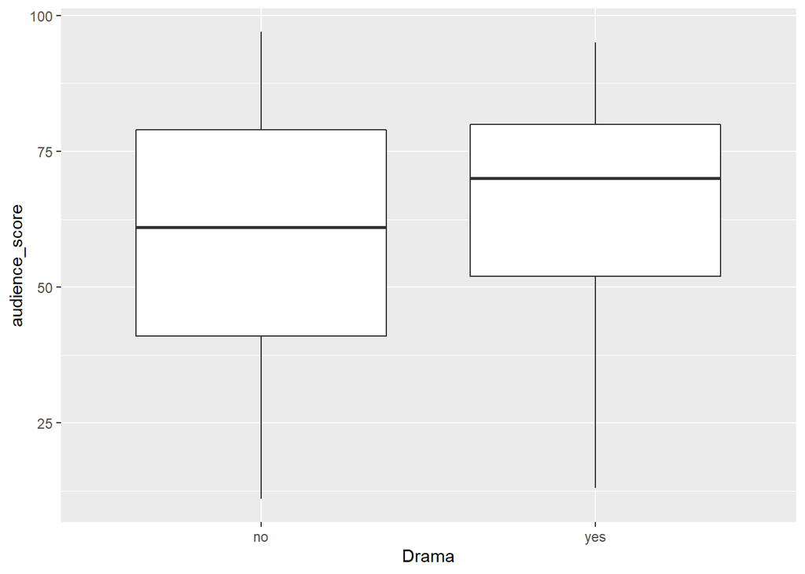

```r
ggplot(data=movies,mapping = aes(x=Drama,y=audience_score))+geom_boxplot()
```

```r
movies%>%
 group_by(Drama) %>%
 summarise(mean_score=mean(audience_score),Std.Dev.=sd(audience_score),max_score=
                   max(audience_score),min_score=min(audience_score))
```

```
## # A tibble: 2 x 5
##   Drama mean_score Std.Dev. max_score min_score
##   <chr>      <dbl>    <dbl>     <dbl>     <dbl>
## 1 no          59.7     21.3        97        11
## 2 yes         65.3     18.5        95        13
```

Again here we can see that drama movies received the higher audience score. Then like the feature movies, we can say drama movies are more likable by audiences.

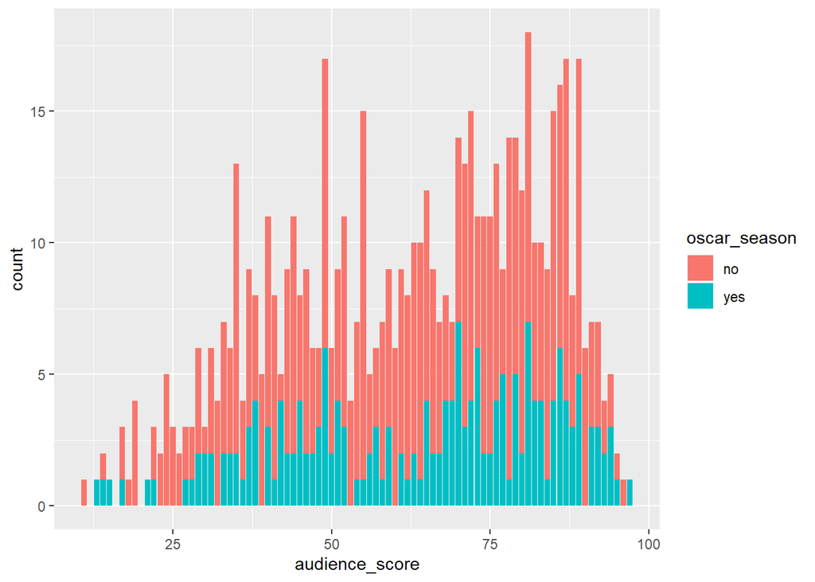

```r
ggplot(data=movies, aes(x = audience_score, fill = oscar_season)) +
  geom_bar()
```

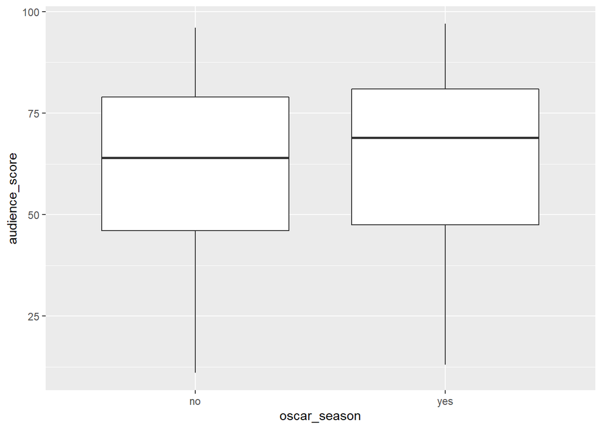

```r
ggplot(data=movies,mapping = aes(x=oscar_season,y=audience_score))+geom_boxplot()
```

```r
movies%>%
 group_by(oscar_season) %>%
 summarise(mean_score=mean(audience_score),Std.Dev.=sd(audience_score),max_score=
                   max(audience_score),min_score=min(audience_score))
```

```
## # A tibble: 2 x 5
##   oscar_season mean_score Std.Dev. max_score min_score
##   <chr>             <dbl>    <dbl>     <dbl>     <dbl>
## 1 no                 61.8     20.1        96        11
## 2 yes                63.7     20.5        97        13
```

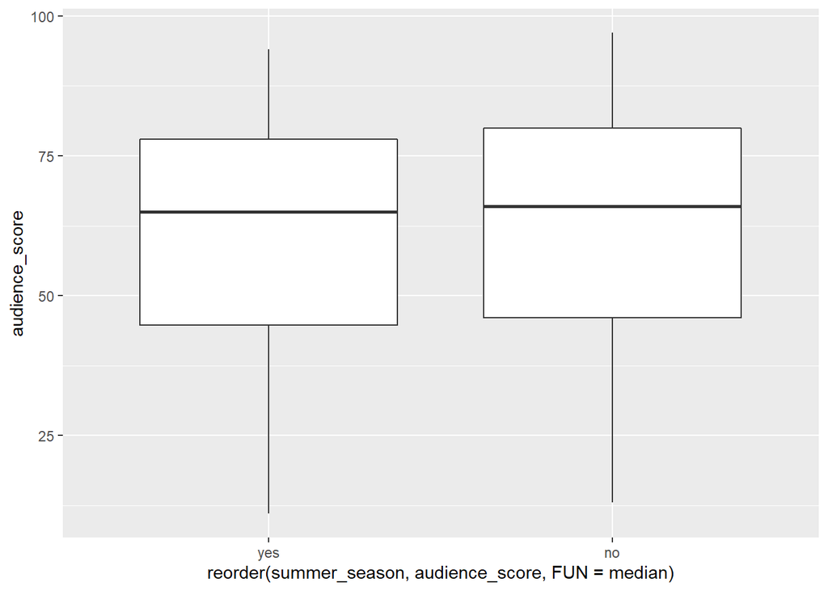

```r
ggplot(data=movies,mapping = aes(x=reorder(summer_season,audience_score,FUN =median) ,y=audience_score))+geom_boxplot()
```

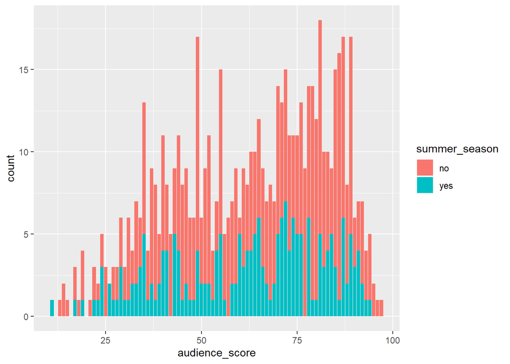

```r
ggplot(data=movies, aes(x = audience_score, fill = summer_season)) +
  geom_bar()
```

```r
movies%>%
 group_by(summer_season) %>%
 summarise(mean_score=mean(audience_score),Std.Dev.=sd(audience_score),max_score=
                   max(audience_score),min_score=min(audience_score))
```

```
## # A tibble: 2 x 5
##   summer_season mean_score Std.Dev. max_score min_score
##   <chr>              <dbl>    <dbl>     <dbl>     <dbl>
## 1 no                  62.6     20.4        97        13
## 2 yes                 61.8     19.9        94        11
```

From the above, we can conclude that the time of the releasing movies in Oscar season or summer doesn’t have a visible impact on the audience score.

## Part 4: Modeling

```r
data.movies=data.frame(
             feature_film=movies$feature_film,
             drama=movies$Drama,
             runtime=movies$runtime,
             mpaa_rating_R=movies$mpaa_rating_R,
             thtr_rel_year=movies$thtr_rel_year,
             oscar_season=movies$oscar_season,
             summer_season=movies$summer_season,
             imdb_rating=movies$imdb_rating,
             imdb_num_votes=movies$imdb_num_votes,
             critics_score=movies$critics_score,
             best_pic_nom=movies$best_pic_nom,
             best_pic_win=movies$best_pic_win,
             best_actor_win=movies$best_actor_win,
             best_actress_win=movies$best_actress_win,
             best_dir_win=movies$best_dir_win,
             top200_box=movies$top200_box,
             audience_score=movies$audience_score
             )
```

```r
if(any(is.na(data.movies))){
        data.movies=na.omit(data.movies)
}
```

```r
movies_ZS=bas.lm(audience_score~.,data=data.movies,
prior="ZS-null",modelprior = uniform(),method = "MCMC")
```

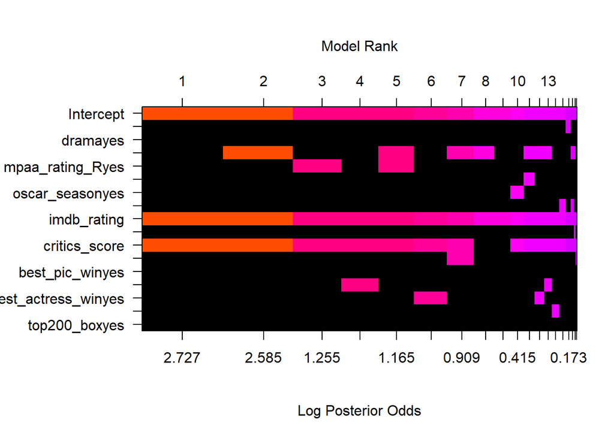

```r
image(movies_ZS,rotate=FALSE)
```

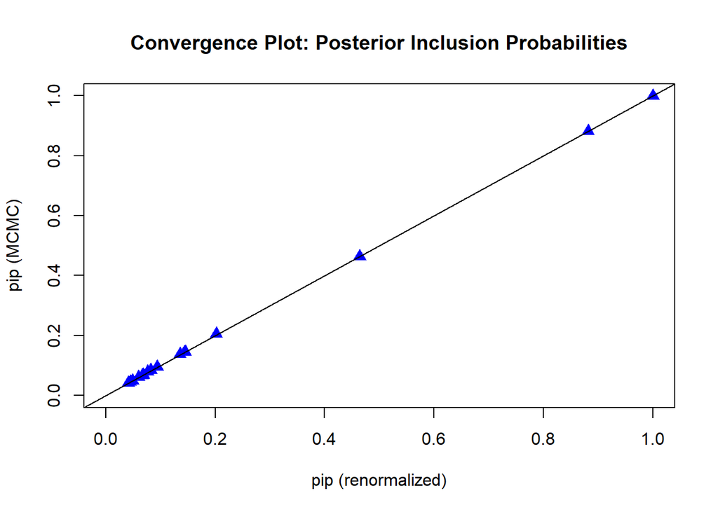

```r
diagnostics(movies_ZS,type = "pip",col="blue",pch=17,cex=1.3)
```

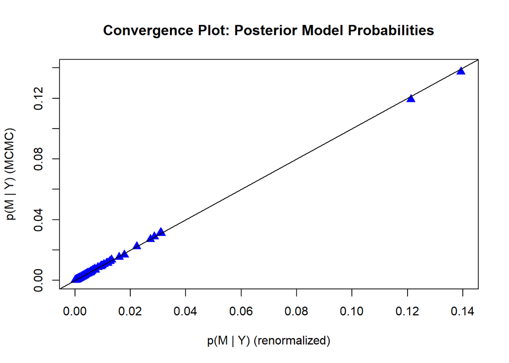

```r
diagnostics(movies_ZS,type = "model",col="blue",pch=17,cex=1.3)
```

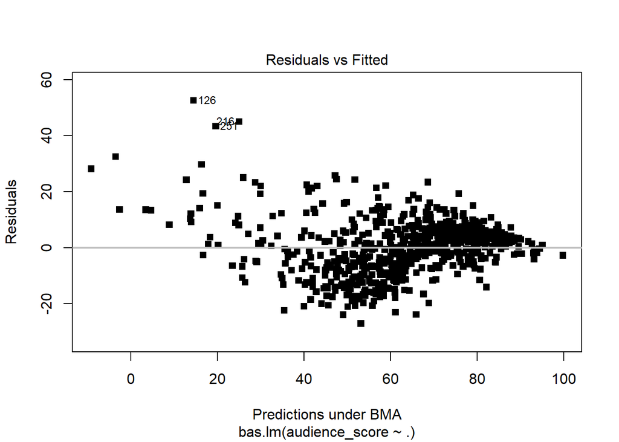

```r
plot(movies_ZS,which=1,ask=FALSE,add.smooth = FALSE,pch=15)
abline(a=0,b=0,col="grey",lwd=2)
```

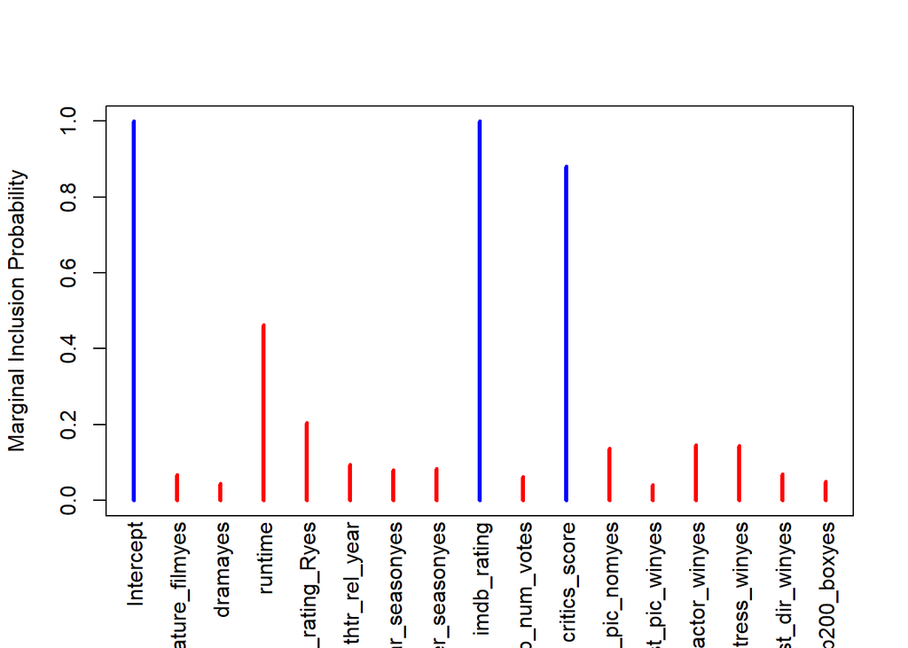

```r
plot(movies_ZS, which=4, ask = FALSE, caption = "", sub.caption = "",
     col.in = "blue", col.ex = "red", lwd = 3)
```

```r
summary(movies_ZS)
```

```
##                     P(B != 0 | Y)  model 1     model 2     model 3
## Intercept              1.00000000   1.0000   1.0000000   1.0000000
## feature_filmyes        0.06724625   0.0000   0.0000000   0.0000000
## dramayes               0.04482651   0.0000   0.0000000   0.0000000
## runtime                0.46365356   0.0000   1.0000000   0.0000000
## mpaa_rating_Ryes       0.20498199   0.0000   0.0000000   1.0000000
## thtr_rel_year          0.09510574   0.0000   0.0000000   0.0000000
## oscar_seasonyes        0.07985992   0.0000   0.0000000   0.0000000
## summer_seasonyes       0.08409042   0.0000   0.0000000   0.0000000
## imdb_rating            0.99996185   1.0000   1.0000000   1.0000000
## imdb_num_votes         0.06195984   0.0000   0.0000000   0.0000000
## critics_score          0.88152847   1.0000   1.0000000   1.0000000
## best_pic_nomyes        0.13806305   0.0000   0.0000000   0.0000000
## best_pic_winyes        0.04170914   0.0000   0.0000000   0.0000000
## best_actor_winyes      0.14557571   0.0000   0.0000000   0.0000000
## best_actress_winyes    0.14439087   0.0000   0.0000000   0.0000000
## best_dir_winyes        0.06901855   0.0000   0.0000000   0.0000000
## top200_boxyes          0.04973602   0.0000   0.0000000   0.0000000
## BF                             NA   1.0000   0.8702806   0.2217602
## PostProbs                      NA   0.1375   0.1193000   0.0316000
## R2                             NA   0.7525   0.7549000   0.7539000
## dim                            NA   3.0000   4.0000000   4.0000000
## logmarg                        NA 443.9495 443.8105657 442.4433468
##                         model 4     model 5
## Intercept             1.0000000   1.0000000
## feature_filmyes       0.0000000   0.0000000
## dramayes              0.0000000   0.0000000
## runtime               0.0000000   1.0000000
## mpaa_rating_Ryes      0.0000000   1.0000000
## thtr_rel_year         0.0000000   0.0000000
## oscar_seasonyes       0.0000000   0.0000000
## summer_seasonyes      0.0000000   0.0000000
## imdb_rating           1.0000000   1.0000000
## imdb_num_votes        0.0000000   0.0000000
## critics_score         1.0000000   1.0000000
## best_pic_nomyes       0.0000000   0.0000000
## best_pic_winyes       0.0000000   0.0000000
## best_actor_winyes     1.0000000   0.0000000
## best_actress_winyes   0.0000000   0.0000000
## best_dir_winyes       0.0000000   0.0000000
## top200_boxyes         0.0000000   0.0000000
## BF                    0.2236679   0.2055844
## PostProbs             0.0311000   0.0288000
## R2                    0.7539000   0.7563000
## dim                   4.0000000   5.0000000
## logmarg             442.4519125 442.3676066
```

```r
coef.movies=coef(movies_ZS)
round(confint(coef.movies),4)
```

```
##                        2.5%   97.5%    beta
## Intercept           61.5811 63.1036 62.3477
## feature_filmyes     -1.3998  0.0631 -0.1076
## dramayes             0.0000  0.0000  0.0172
## runtime             -0.0820  0.0000 -0.0253
## mpaa_rating_Ryes    -2.1509  0.0000 -0.3107
## thtr_rel_year       -0.0546  0.0000 -0.0048
## oscar_seasonyes     -1.1419  0.0000 -0.0847
## summer_seasonyes     0.0000  0.9849  0.0905
## imdb_rating         13.6129 16.5139 14.9629
## imdb_num_votes       0.0000  0.0000  0.0000
## critics_score        0.0000  0.1045  0.0623
## best_pic_nomyes     -0.0047  5.1482  0.5373
## best_pic_winyes      0.0000  0.0000 -0.0109
## best_actor_winyes   -2.6566  0.0000 -0.2883
## best_actress_winyes -2.8968  0.0001 -0.3146
## best_dir_winyes     -1.3223  0.1001 -0.1223
## top200_boxyes        0.0000  0.3682  0.0899
## attr(,"Probability")
## [1] 0.95
## attr(,"class")
## [1] "confint.bas"
```

## Part 5: Prediction

```r
lalaLand=data.frame(feature_film="yes",
                    drama="yes",
                    runtime=128,
                    mpaa_rating_R="no",
                    thtr_rel_year=2016,
                    oscar_season="yes",
                    summer_season="no",
                    imdb_rating=8.0,
                    imdb_num_votes=104424,
                    critics_score=93,
                    best_pic_nom="yes",
                    best_pic_win="no",
                    best_actor_win="no",
                    best_actress_win="yes",
                    best_dir_win="yes",
                    top200_box="yes")

movies.Predict=predict(movies_ZS,estimator = "BPM",lalaLand,interval="predict",se.fit = TRUE)
data.frame("Movie"="La La Land","Predicted Audience Score"=movies.Predict$Ybma,"Real Audience Score"=81)
```

```
##        Movie Predicted.Audience.Score Real.Audience.Score
## 1 La La Land                 86.80696                  81
```

The data about LaLa Land comes from the website of the Los Angeles Time (https://envelope.latimes.com/awards/titles/la-la-land/) and Rotten Tomatoes (https://www.rottentomatoes.com/m/la_la_land)